# Midterm

## **Midterm Exam/Project**

Due Sunday, October 22nd, 2023 by midnight Pacific Time.

**The report should have the following sections: Introduction (provide background on your dataset and formulated question), Methods (include how and where the data were acquired, how you cleaned and wrangled the data, what tools you used for data exploration), Preliminary Results (provide summary statistics in tabular form and publication-quality figures, take a look at the kable function from knitr to write nice tables in Rmarkdown), and a brief Conclusion about what you found in terms of the formulated question.**

**Introduction**

The primary dataset belongs to the Centers for Disease Control and Prevention (CDC) and contains data regarding 5 common foodborne and waterborne diseases found across the USA. The 5 diseases of interest are vibrio, shiga toxin-producing escherichia coli (STEC), shigella, salmonella, and campylobacter. It is known that for the common flu, winter time is typically the highest rate of transmission and the highest number of cases are during those months. Here, the primary question will be to see if these foodborne and waterborne diseases follow a similar trend if they are more prevalent when the temperatures are low or if they are more prevalent when the temperature is higher, and will be measured by the number of isolates of the diseases. Isolates are the number of cases for that particular disease. Using this information, we will be able to ascertain whether the food and water borne illnesses are more prevalent during the colder or warmer times of the year. In addition, for exploratory purposes, the summary statistics of the 5 pathogens will be looked at as well to see if there is a particular pathogen that causes more cases than others and how spread out all 5 of them are, in terms of isolates.

**Methods**

In the CDC dataset, there are 10 different cities where data was collected across various regions in the mainland United States, ranging from the east coast to the west coast and northern cities to southern cities. The importance of having a wide range of cities in this study is to eliminate potential confounders that can arise from different geographical areas due to population size, average temperature, cultural, and others. For example, foodborne illnesses are more commonly found in seafood so one may say that a city like Boston, where people typically eat more seafood than a place such as Kansas City. The cities were all accumulated into the average and median temperature and isolate values due to this reasoning.

The monthly temperature values were gathered from The National Oceanic and Atmospheric Administration (NOAA) and produced onto an excel sheet which was later merged into the CDC dataset based on the city (HHS_Region) and month. Due to a very negligible to no deviation in temperatures and unfinished 2023 data, since the year is not yet over, the average temperatures were gathered for the month, regardless of the year being 2022 or 2023.

The data was checked to make sure there were no missing values found in any of the variable categories. The dimensions, footers, and headers were all verified using the dim, nrow, and ncol functions. The variable types made sense and were not changed and were assessed with the str, summary, and table functions. All the values in temperature, isolates, and months/quarters were plausible and made sense. The variable “Past two years average” for isolates were not utilized in this assignment as the values were not making sense. If you calculated for the averages for the same month, pathogen, and city, it would not equate to the correct calculated values from 2022-2023 given in the dataset. It appears it might have been calculated for 2021-2022 perhaps, but due to the lack of confirmation, it was not used.

```r
library(data.table)
library(dplyr)
library(dtplyr)
library(quarto)
library(knitr)
library(readxl)
library(kableExtra)
## Reading in main data and temperature data and merging them.
beam <- data.table::fread("/Users/vikaskunta/Downloads/BEAM_Dashboard_-_Isolates_by_HHS_Region_20231016.csv")
weather_temps_monthly <- read_excel("weather temps monthly.xlsx")
merge <- beam %>%
     left_join(weather_temps_monthly, by = c("HHS_Region", "Month"))
```

**Preliminary Results**

The results for the monthly temperature obviously showed that the highest average temperatures were in the summer time, with June, July, and August being the 3 highest temperature months and the 3 lowest temperature months being December, January, and February. Interestingly enough, the results for the number of pathogen isolates per month in terms of highest and lowest, were the exact same as the average temperature months. This would mean that the majority of pathogens spread during the summer time and are more stagnant towards the winter time and cooler months of the year.

To answer the side question that was mentioned in the introduction, the number of isolates by pathogen were assessed by running a summary statistic on them. It showed that salmonella was, by far, the most common pathogen that was spread in this dataset and vibrio being the least common one, in terms of the average amount of pathogens per month across the various cities.

Bar graphs were the best form of visual representation for all 3 of these tables that were generated. It was interesting to see the similarity of the two graphs, depicting the isolate values and temperature values, both having a somewhat bell curve like look to it with the middle months being the highest and the early and late months being the lowest.

```r
library(ggplot2)

## Summary Statistics of Monthly Temperature and Isolates. Pathogen summary stats included as well.

monthstat <- merge %>%
    group_by(Month) %>%
    summarize(
        Mean_Temp = mean(Temperature),
        Median_Temp = median(Temperature),
        Std_Dev_Temp = sd(Temperature),
        Min_Temp = min(Temperature),
        Max_Temp = max(Temperature),
        N = n()
    )

isostat <- merge %>%
    group_by(Month) %>%
    summarize(
        Mean_Iso = mean(Number_of_isolates),
        Median_Iso = median(Number_of_isolates),
        Std_Dev_Iso = sd(Number_of_isolates),
        Min_Iso = min(Number_of_isolates),
        Max_Iso = max(Number_of_isolates),
        N = n()
    )
patstat <- merge %>%
    group_by(Pathogen) %>%
    summarize(
        Mean_Iso = mean(Number_of_isolates),
        Median_Iso = median(Number_of_isolates),
        Std_Dev_Iso = sd(Number_of_isolates),
        Min_Iso = min(Number_of_isolates),
        Max_Iso = max(Number_of_isolates),
    )

## Tables

knitr::kable(monthstat[, 1:7], "simple", caption = "Summary Statistics of Temperature by Month")
```

Summary Statistics of Temperature by Month

| Month | Mean_Temp | Median_Temp | Std_Dev_Temp | Min_Temp | Max_Temp | N |
| --- | --- | --- | --- | --- | --- | --- |
| 1 | 36.9 | 33.0 | 7.816713 | 27 | 51 | 100 |
| 2 | 39.5 | 35.0 | 7.955050 | 30 | 54 | 100 |
| 3 | 46.6 | 44.5 | 6.759953 | 38 | 58 | 100 |
| 4 | 54.7 | 53.5 | 5.578639 | 48 | 66 | 100 |
| 5 | 62.9 | 61.0 | 5.402020 | 57 | 74 | 100 |
| 6 | 71.0 | 71.0 | 6.244189 | 61 | 82 | 100 |
| 7 | 75.3 | 76.5 | 6.483078 | 62 | 85 | 100 |
| 8 | 74.4 | 75.5 | 6.279677 | 62 | 86 | 100 |
| 9 | 68.0 | 68.0 | 4.517083 | 62 | 78 | 100 |
| 10 | 57.9 | 57.5 | 4.726176 | 52 | 68 | 50 |
| 11 | 47.7 | 46.0 | 5.661362 | 41 | 57 | 50 |
| 12 | 39.0 | 36.5 | 6.624013 | 32 | 51 | 50 |

```r
knitr::kable(isostat[, 1:7], "simple", caption = "Summary Statistics of Isolates by Month")
```

Summary Statistics of Isolates by Month

| Month | Mean_Iso | Median_Iso | Std_Dev_Iso | Min_Iso | Max_Iso | N |
| --- | --- | --- | --- | --- | --- | --- |
| 1 | 62.28 | 19.5 | 110.09904 | 0 | 609 | 100 |
| 2 | 52.79 | 18.5 | 89.74198 | 0 | 431 | 100 |
| 3 | 68.18 | 25.5 | 114.18215 | 0 | 578 | 100 |
| 4 | 78.52 | 28.0 | 135.66570 | 0 | 724 | 100 |
| 5 | 102.31 | 32.5 | 180.28847 | 0 | 916 | 100 |
| 6 | 123.21 | 38.5 | 231.49419 | 0 | 1344 | 100 |
| 7 | 150.17 | 43.5 | 282.50238 | 1 | 1665 | 100 |
| 8 | 158.66 | 46.0 | 297.95682 | 0 | 1760 | 100 |
| 9 | 109.79 | 21.5 | 247.03708 | 0 | 1756 | 100 |
| 10 | 116.34 | 34.0 | 242.70933 | 0 | 1376 | 50 |
| 11 | 82.12 | 29.0 | 164.26617 | 0 | 943 | 50 |
| 12 | 68.54 | 21.0 | 128.40644 | 0 | 701 | 50 |

```r
knitr::kable(patstat, "simple", caption = "Summary Statistics of the Isolates for Each Pathogen")
```

Summary Statistics of the Isolates for Each Pathogen

| Pathogen | Mean_Iso | Median_Iso | Std_Dev_Iso | Min_Iso | Max_Iso |
| --- | --- | --- | --- | --- | --- |
| Campylobacter | 29.652381 | 15.5 | 33.563453 | 0 | 148 |
| STEC | 55.838095 | 48.5 | 38.443054 | 6 | 286 |
| Salmonella | 375.419048 | 274.5 | 320.982352 | 60 | 1760 |
| Shigella | 28.938095 | 18.5 | 32.091093 | 0 | 159 |
| Vibrio | 5.109524 | 2.5 | 7.030515 | 0 | 53 |

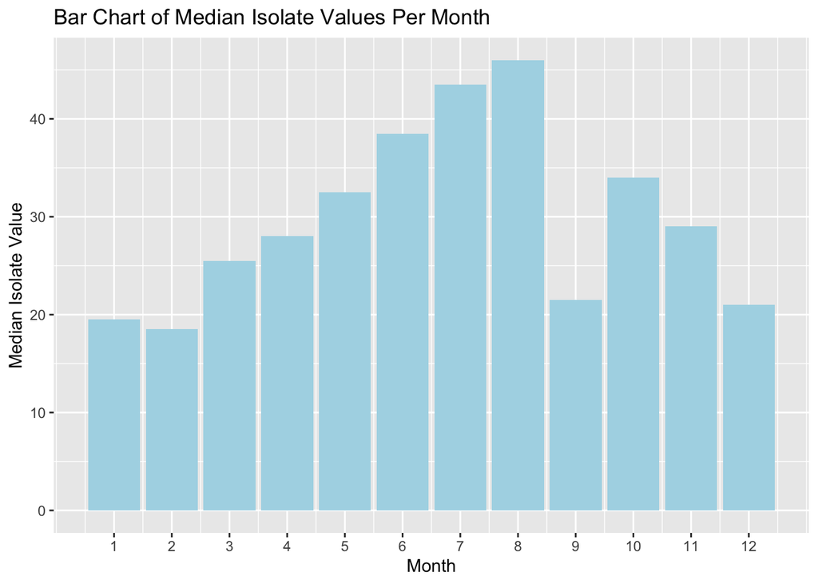

```r
## Figures

ggplot(data = isostat, aes(x = Month, y = Median_Iso)) +
  geom_bar(stat = "identity", fill = "lightblue") +
  labs(x = "Month", y = "Median Isolate Value") +
  ggtitle("Bar Chart of Median Isolate Values Per Month") +
  scale_x_continuous(breaks = 1:12, labels = 1:12)
```

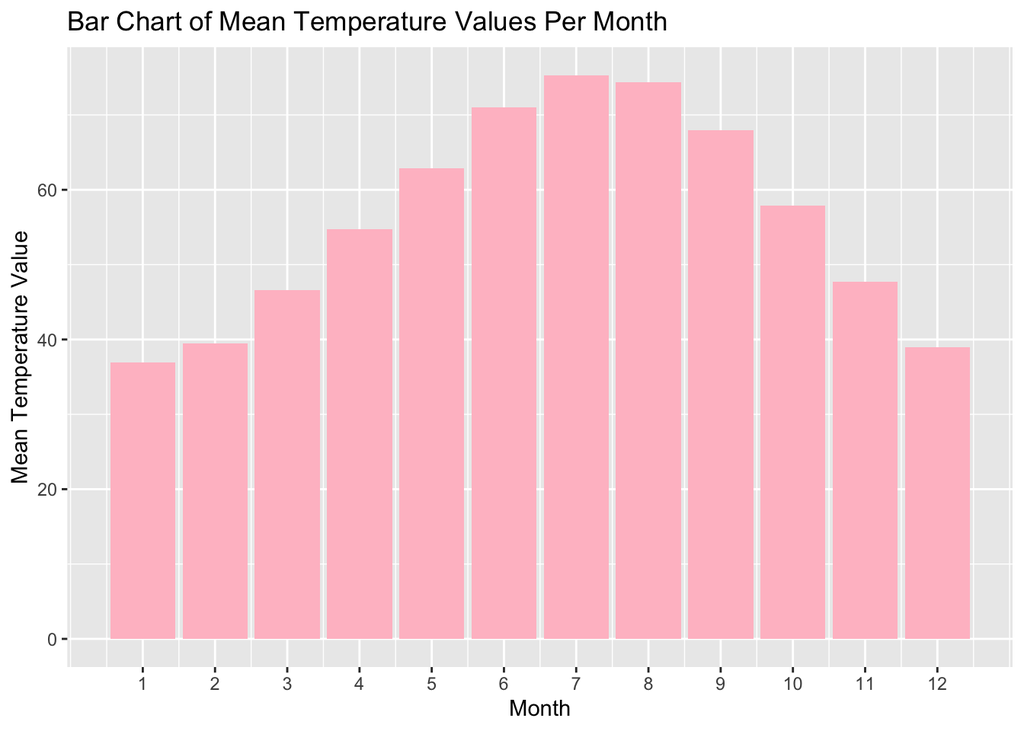

```r
ggplot(data = monthstat, aes(x = Month, y = Mean_Temp)) +
  geom_bar(stat = "identity", fill = "pink") +
  labs(x = "Month", y = "Mean Temperature Value") +
  ggtitle("Bar Chart of Mean Temperature Values Per Month") +
  scale_x_continuous(breaks = 1:12, labels = 1:12)
```

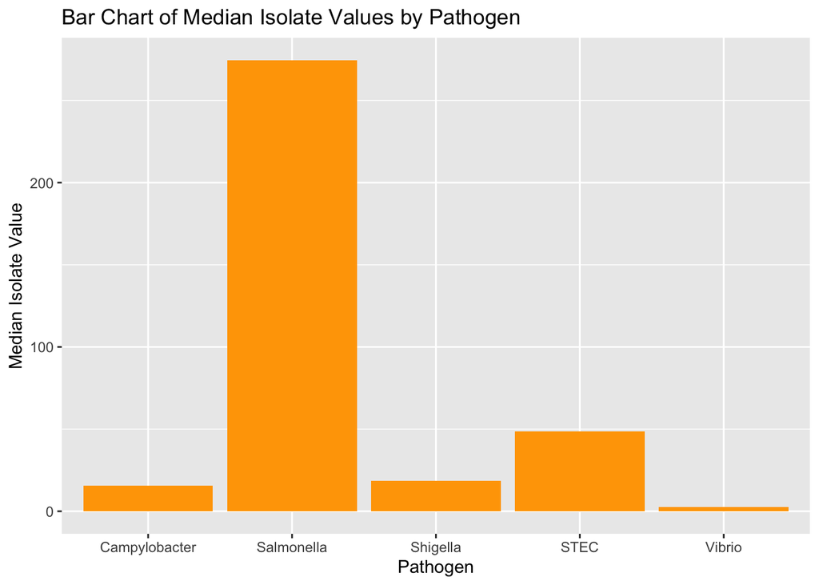

```r
ggplot(data = patstat, aes(x = Pathogen, y = Median_Iso)) +
  geom_bar(stat = "identity", fill = "orange") +
  labs(x = "Pathogen", y = "Median Isolate Value") +
  ggtitle("Bar Chart of Median Isolate Values by Pathogen")
```

**Conclusion**

In conclusion, unlike the flu, where the highest cases appear in the winter time (lowest temperature months), the 5 common food and water borne illnesses that were utilized in this study show that the highest number of cases are in the summer time (highest temperature months). This would suggest that those pathogens spread, grow, and survive better in warmer temperatures than colder ones. Salmonella was by far the most common type of pathogen in this dataset.